[figure not shown]

### **R Training: The new Excel, and more**!

This resource is an introduction to the R programming language. It can be used as standalone learning tool, or as part of training sessions.

It takes you through from the first steps of opening RStudio through using it for visualisations such as graphs and maps - basically an introduction to using R for simple but effective data management, manipulation, calculations, and visualisation.

It does however work on the assumption that [R and R Studio](https://www.rstudio.com/products/rstudio/download/) are already installed.

#### **Training Contents**

1. Getting set up:
   - Opening R Studio
   - RStudio layout
   - Setting up a project
2. The data
3. General coding practice:
   - Objects
   - Comments
4. Loading in and exploring data:
   - Loading in data
   - Basic dataframe functions
   - Selection certain columns/removing columns
5. Manipulating dataframes:
   - Conditional selections
   - Altering data in dataframes
   - Writing data
6. dplyr:
   - Packages
   - The Pipe
   - Joining
   - Selecting
   - Pivoting
   - Filtering
   - Mutating
7. Graphs:
   - ggplot
   - Scatter plots
   - Bar charts
   - Line graphs
   - Displaying a third variable
   - Styles
8. Statistical Operations:
   - Minimum, Maximum, and Range
   - Averages
   - Correlation
   - Significance Testing
9. Iteration:
   - if statements
   - for loops
   - while loops
   - How could we use loops?
10. Functions:
    - Writing functions
    - Applying functions repetitively
11. Maps:
    - Geospatial data
    - Point maps
    - Chloropleth maps
12. R Markdown:
    - Text
    - Code
    - Multiple reports

The format of the training is as follows:

- Text describing what we will be doing
- Code showing what needs typing in:

```r
print("Hello world")
```

- Activities for you to do to put your learning to the test

**Activity A0.1:** Write a line of code that prints the string “Hello world”

- Little tips to make writing code easier

**Tip:**  
R is better than Excel

#### **The data** (back to contents)

We’re going to use the publicly available underlying data from the Department for Education’s School Workforce Census, an annual census (collected every November and published in the following July) of every single teacher in England. The statistical report for 2016 can be found [here](https://www.gov.uk/government/statistics/school-workforce-in-england-november-2016) and the Excel version of the underlying data [here](https://www.gov.uk/government/uploads/system/uploads/attachment_data/file/620828/SFR25_2017_Underlying_Data.xlsx). However, in this form it is not in particularly machine-readable format (see [here](http://opendatahandbook.org/glossary/en/terms/machine-readable/) for a definition of machine readable).

So, [here](https://drive.google.com/file/d/0B5-bg4xFFu09dmsxYm8yZGVEdVE/view) is a link to a CSV (CSV stands for Comma-Seperated Value, a type of [delimited file type](https://en.wikipedia.org/wiki/Delimiter-separated_values)).

You will need to:

1. Click on the link
2. Download the data
3. Set up a folder somewhere sensible/easily accessible in your Documents folder
4. Move the file to that folder

#### **Getting set up** (back to contents)

##### **Opening R Studio:**

First thing, open up R Studio!

Either find the RStudio icon on your desktop/start menu, or search for it in the start menu search (this is assuming you are using a Windows computer):

[figure not shown]

##### **R Studio Layout:**

Clink on it and the R Studio interface will open, and will look like this:

[figure not shown]

There are four panes in an R Studio window:

##### **Setting up a project:**

  Analysis in R is carried out in ‘projects’. A ‘project’ creates an space which contains all of the inputs, code, and outputs that relate to the analysis.

**Activity A3.1:** Create a new project:

1. Click on File
2. Click on New Project
3. Click on New Directory
4. Click on Empty Project
5. In ‘Directory name’ type R_training
6. In ‘Create project as subdirectory of’ select a folder that you commonly use, like Documents
7. Click ‘Create project’
8. Click File
9. Click New File
10. Click R Script

Great, we’ve now created a project - all pieces of analysis should start with a project.

We now need to put some stuff in it.

**Activity A3.2:** Set up your folder structure:

1. Open up your file explorer and navigate to the directory (folder) you just created in R Studio
2. Create the following folders:
   - 1_data
   - 2_code
   - 3_outputs
   - 9_misc
3. Move the data you’ve been sent into 1_data

We can now view this environment within R Studio - click on ‘Files’ in the bottom right console.

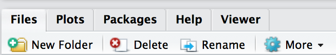

#### **General Coding Practice** (back to contents)

##### **Objects:**

Objects are any ‘thing’ that you create in R. They’re shown in your Environment.

There are a huge number of objects. The code below produces a few of these types of objects:

```r
my_string <- 'DfE'
my_number <- 2017
my_boolean <- TRUE
my_list <- list(1,2,3,4,5)
my_dataframe <- data.frame(var1 = c(1,2,3,4,5),
                           var2 = c("a","b","c","d","e"))
```

There - written your first lines of code in R!

**Tip:**

There are a number of different ways you can write names in R:

- snake_case: lower case, separated by underscores
- CamelCase: each word starts with an upper case letter
- kebab-case: lower case, separated by hyphens

However, we still need to run that code. You’ll need to place your cursor somewhere in the line you want to run, or if it’s multiple lines highlight them. To initiate the code you can:

- Press CTRL + ENTER
- Click ‘Run’ in the top right hand corner of the script window

**Tip:**

- Double click highlights term
- Triple click highlights line
- Quadruple click highlights entire script

The <- sign is called a get sign. It ‘gets’ the output from the right hand side and attributes it to the object name.

**Tip:**

ALT + - is a shortcut to inputting the get sign.

**Activity A3.3:** What does typeof(OBJECT NAME) do?

**Activity A3.4:** Now save your work in the 2_code folder!

Writing the following code will remove a specified object:

```r
rm(object_name)
```

Writing the following code will remove all objects:

```r
rm(list = ls())
```

**Activity A3.5:** Arguments are the bits of code inside brackets, and if there are multiple arguments they’re separated by commas.

Explain the what the argument inside the second rm in the code above does.

##### **Comments:**

**Activity A3.6:** Type 1+1 and run it, what comes up in the console? Put a # in front of 1+1, what comes up in the console?

Comments are really important for annotating code, so that you and others know exactly what the code does and why.

```r
#Remove all objects
rm(list = ls())
```

**Tip:**

- CTRL + SHIFT + C comments multiple lines at once
- CTRL + SHIFT + R creates a section, which you can jump between using the dropdown list in the bottom left corner of the script window

#### **Loading and Exploring Data** (back to contents)

##### **Loading in data:**

The most common process to load in data is to load in a CSV file.

```r
#Load in data
swfc_16_init <- read.csv("1_data/swfc_2016_machine_readable.csv")
swfc_16 <- swfc_16_init
```

**Tip:** Load in and create and initial, raw version of the file, and never do anything to that object. This means if you muck anything up, you’ll always have a clean dataset to start again from. This is particularly important when loading in big dataframes, such as those from SQL.

##### **Basic dataframe functions:**

There are a number of functions which can be used to gain a summary of data:

```r
#Basic dataframe exploration functions
summary(swfc_16) #Get a summary of each variable
```

**Tip:** This worksheet is built using an add on to R called R Markdown, which integrates code, text, and images. We’ll come on to how to create R Markdown documents later, but for now, the box below with a white background and grey border is an output from the above code as it renders in R Markdown. Remember this, it will appear a lot in the worksheet.

```
##    LA_Number     Establishment_Number  LAEstab_2016
##  Min.   :201.0   Min.   :1000         Min.   :2013614
##  1st Qu.:371.0   1st Qu.:2115         1st Qu.:3712144
##  Median :850.0   Median :3001         Median :8502761
##  Mean   :697.6   Mean   :3133         Mean   :6979196
##  3rd Qu.:891.0   3rd Qu.:3605         3rd Qu.:8912352
##  Max.   :938.0   Max.   :7750         Max.   :9387022
##
##           LA_Name           URN
##  Lancashire   :  632   Min.   :100000
##  Kent         :  581   1st Qu.:110587
##  Essex        :  556   Median :120528
##  Hertfordshire:  535   Mean   :122340
##  Hampshire    :  531   3rd Qu.:137029
##  Birmingham   :  447   Max.   :143768
##  (Other)      :18631
##                                School_Name
##  St Joseph's Catholic Primary School :   57
##  St Mary's Catholic Primary School   :   41
##  St Anne's Catholic Primary School   :   20
##  St Patrick's Catholic Primary School:   20
##  Holy Family Catholic Primary School :   19
##  St Peter's Catholic Primary School  :   18
##  (Other)                             :21738
```

```r
head(swfc_16) #Get the top 6 rows
```

```
##   LA_Number Establishment_Number LAEstab_2016    LA_Name    URN
## 1       331                 4004      3314004   Coventry 141104
## 2       332                 2010      3322010     Dudley 103774
## 3       330                 4010      3304010 Birmingham 139788
## 4       332                 2012      3322012     Dudley 103775
## 5       332                 2043      3322043     Dudley 103781
## 6       210                 1025      2101025  Southwark 100768
##                           School_Name
## 1                         Seva School
## 2 Kates Hill Community Primary School
## 3             Waverley Studio College
## 4      Northfield Road Primary School
## 5         Dawley Brook Primary School
## 6          Ann Bernadt Nursery School
```

```r
tail(swfc_16) #Get the bottom 6 rows
```

```
##       LA_Number Establishment_Number LAEstab_2016         LA_Name    URN
## 21908       855                 2092      8552092  Leicestershire 143250
## 21909       831                 2424      8312424           Derby 112728
## 21910       882                 2105      8822105 Southend-on-Sea 143341
## 21911       936                 2269      9362269          Surrey 142433
## 21912       931                 2561      9312561     Oxfordshire 137992
## 21913       831                 1009      8311009           Derby 112475
##                          School_Name
## 21908       Newcroft Primary Academy
## 21909        Pear Tree Infant School
## 21910 Thorpe Greenways Infant School
## 21911      Lightwater Village School
## 21912        Faringdon Infant School
## 21913        Walbrook Nursery School
```

```r
colnames(swfc_16) #Get list of column names
```

```
##  [1] "LA_Number"
##  [2] "Establishment_Number"
##  [3] "LAEstab_2016"
##  [4] "LA_Name"
##  [5] "URN"
##  [6] "School_Name"
##  [7] "School_Type_Description"
##  [8] "School_Type"
##  [9] "School_Phase"
## [10] "Religious_Character"
## [11] "Government_Office_Region_Name"
## [12] "Parliamentary_Constituency"
## [13] "LA_District"
## [14] "Ward"
## [15] "StatutoryLowAge"
```

[output cut: 44 more lines]

**Tip:**

Click on the name of a dataframe to open it in a new window. Click on the arrow to the left of it to see the structure of it, or type str(DATAFRAME_NAME)

We can also change column names using the above function:

```r
#Identify the column number using colnames(swfc_16) and then specify the string to change it to
colnames(swfc_16)[11] <- "Region"

#...and change it back again
colnames(swfc_16)[11] <- "Government_Office_Region_Name"
```

##### **Selecting certain columns/removing columns:**

```r
teacher_absences <- swfc_16[,c(2,53:55)]
```

Let’s break this down:

1. teacher_absences is the name of the new dataframe we’re going to create
2. We’ve seen the get sign before
3. swfc_16 is the dataframe we’re going to select columns from
4. [] is for selecting a certain element from an object
5. c() stipulates a character string, in this instance a load of numbers
6. x:y means all numbers between and including x and y
7. The comma and nothing before it signifies that all rows must be included - the format is dataframe[row conditions, column conditions]

Whilst we can use this method to remove columns, we can also remove individual columns using a simpler method. Say for instance we wanted to remove the 2016 LA Establishment Code, the third column:

```r
swfc_16 <- swfc_16[,-3]
```

#### **Manipulating Dataframes** (back to contents)

##### **Conditional selections:**

We can select subsets of dataframes based on certain conditions. There are a number of ways to do it, but this method uses functions in the basic R set of functions, known as ‘base R’:

```r
#Conditionally select primary schools
swfc_16_pri <- swfc_16[swfc_16$School_Phase == "Primary",]
```

Let’s break this down:

1. swfc_16_pri is the name of the new dataframe we’re going to create
2. We’ve seen the get sign before
3. swfc_16 is the dataframe we’re going to conditionally select rows from
4. [] is for selecting a certain element from an object
5. $ is for extracting an element by name, in this instance the School_Phase column
6. ==“Primary” signifies that rows must equal Primary
7. The comma and then nothing after it signifies that all columns must be included - the format is dataframe[row conditions, column conditions]

**Activity A5.1:** Use conditional selections to create a new dataframe which contains all schools whose school type is an academy. Open the dataframe to see what an academy is actually called in School_Type.

**Tip:**

After typing the dollar sign when looking for dataframe column names, pause, and a dropdown list will appear.

We can also use selections on numerical variables too:

```r
swfc_16_male <- swfc_16[swfc_16$Perc_Male_Teachers > 50,]
```

However, we’re not limited to just one condition:

```r
#Conditionally select schools where Pupil:Teacher Ratios are below 20 and above or equal to 10
swfc_16_ptr <- swfc_16[(swfc_16$Pupil_Teacher_Ratio < 20 & swfc_16$Pupil_Teacher_Ratio >=10),]

#Conditionally select schools where Pupil:Teacher Ratios are below 10 or their LA is in Camden
swfc_16_ptr_camden <- swfc_16[(swfc_16$Pupil_Teacher_Ratio < 10 | swfc_16$LA_Name == "Camden"),]
```

**Activity A5.2:** Select all schools whose StatutoryLowAge is higher than 5 and have no full time posts vacant (the fourth from last column).

##### **Altering data in dataframes:**

Editing dataframes is a key skill. We can edit the data within columns, or create new ones.

Here we edit the Religious_Character to be TRUE or FALSE. The Religious_Character column is a column of factors - strings limited to a certain number of entries. We will first turn it into a column which can contain any string, called a character column.

**Tip:**

If a column is a factor, you can see what the different entries are through levels(dataframe$column).

```r
#Turn Religious.Character to binary
swfc_16$Religious_Character <- as.character(swfc_16$Religious_Character)

swfc_16$Religious_Character[swfc_16$Religious_Character == 'Does not apply' |
                              swfc_16$Religious_Character == 'None' |
                              swfc_16$Religious_Character == ""] <- FALSE
swfc_16$Religious_Character[swfc_16$Religious_Character != FALSE] <- TRUE
```

This uses boolean logic (TRUE or FALSE). It also uses != which means does not equal.

We can calculate a new column too. In this instance we’ll work out the percentage of teaching staff that are vacancies.

```r
#Calculate percentage of posts which are vacancies
swfc_16$perc_vacancies <- swfc_16$FT_Vacant_Posts/swfc_16$Tot_Teachers_HC
```

**Activity A5.3:** Turn all schools which arent an LA maintained school or a special school into ‘Not LA maintained’.

##### **Writing data:**

**Activity A5.4:** The function for writing is write.csv(). Use the help function (?write.csv) to work out what the arguments are for this function

#### **dplyr“** (back to contents)

##### **Packages:**

One of the great things about R (and lots of other open source programming languages) is that you can add in extra functionality really easy. These extra functions come in the form of packages.

To get a package, we first need to install it. This can be done in the console, as once installed, we don’t need to reinstall every time we start a new session of R.

We are going to install a package called dplyr, a package to manipulate data.

```r
install.packages("dplyr")
```

A lot of funny stuff will come up in your Console, ignore it, it’s all normal (or should be!).

Once we’ve installed it, we have to load the package. This we do have to do every time we start a new session of R.

```r
#Load required libraries
library(dplyr)
```

##### **The pipe:**

The first feature of dplyr is the pipe: %>%.

The pipe allows you turn code into the format of a recipe, carrying out a series of functions one after another. For example, we could turn the name of the school (School_Name) into a character from a factor, as it is not a categorical variable where the records could take one of a fixed number of entries.

In base R, this would look like:

```r
swfc_16$School_Name <- as.character(swfc_16$School_Name)
```

In dplyr this looks like:

```r
swfc_16$School_Name <- swfc_16$School_Name %>% as.character()
```

**Tip:**

You can shortcut to a pipe by CTRL + SHIFT + M.

##### **Joining:**

There are a number of types of joins that dplyr offers. We won’t go through them here as this isn’t what this course is about, but [this post](http://rstudio-pubs-static.s3.amazonaws.com/227171_618ebdce0b9d44f3af65700e833593db.html) goes through them clearly. We will use a left join - keeping all rows on one dataframe, joining another on a certain variable where they match, and making all rows which don’t match ‘not applicable’.

We will create a dataframe which details whether a Government Office Region is in London or the Rest of England and then match it to the rest of the School Workforce Census.

```r
#Create dataframe on whether region is in London or Rest of England
ldn_roe <- data.frame(Government_Office_Region_Name = c("East Midlands", "East of England", "Inner London",
"North East", "North West", "Outer London", "South East", "South West", "West Midlands", "Yorkshire and the Humber"),
ldn_roe = c("RoE","RoE","LDN","RoE","RoE","LDN","RoE","RoE","RoE","RoE"))

#Match to SWFC
swfc_16 <- left_join(swfc_16,LDN_RoE,by="Government_Office_Region_Name")
```

We can also match on column names even if they columns are named differently. But first, we’ll remove the column that we’ve just added in using the ‘select’ function.

##### **Selecting:**

The select function uses column names to select subsets of a dataframe. Individual columns can be selected, separated by columns, or groups of columns, with the starting and ending columns separated by a colon.

```r
#Remove new column
swfc_16 <- select(swfc_16,LA_Number:Perc_FT_Temp_Filled_Posts)

#Or using 'the pipe'

swfc_16 <- swfc_16 %>%
  select(LA_Number:Perc_FT_Temp_Filled_Posts)
```

Now, we can change the name of the first ldn_roe column, and then match again.

```r
#Change name of Government_Office_Region_Name
ldn_roe <- ldn_roe %>%
  select(Region = Government_Office_Region_Name,
          ldn_roe)

#Match to SWFC
swfc_16 <- left_join(swfc_16,ldn_roe,by=c("Government_Office_Region_Name"="Region"))
```

##### **Pivoting:**

Pivoting (grouping data by certain characteristics and then performing certain calculations - counts of each group or averages for each group) is a really popular feature in Excel, and can be replicated using dplyr.

We’re going to create two pivot tables:

- Count the number of each type of school
- Calculate the average % of teachers with Qualified Teacher Status for each school type

The image below shows the boxes from the Excel pivot table user interface with the entries to build the pivot table for the first of the list above.

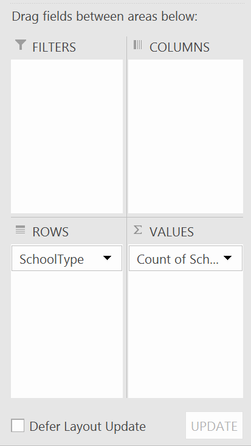

```r
#Calculate the number of schools by school type
school_type_count <- swfc_16 %>% #Set the name of the output object and feed in 'the ingredients' - swfc_16 in this instance
  group_by(School_Type) %>% #Recipe step 1: Specifying the variable we want to group the data by
  summarise(Count_Schools = n()) #Recipe step 2: Define what function we want to apply to the grouped data. Here we are doing a simple count - n(). We also specify the name of the new column, in this instance 'Count_Schools'
```

**Tip:**

To prevent your lines of code being too long you can start new lines after things like %>%, ,, =, and <-.

If you go to ‘Tools’, ‘Global Options’, ‘Code’, ‘Display’ there is an option called ‘Show margin’ which adds a margin after 80 characters as a default - try not to exceed this.

```r
#Calculate average percentage of qualified teachers per school, grouped by school type
av_qts_schooltype <- swfc_16 %>% #Set the name of the output object and feed in 'the ingredients' - swfc_16 in this instance
  group_by(School_Type) %>% #Recipe step 1: Specifying the variable we want to group the data by
  summarise(Ave_Perc_QTS = mean(Perc_QTS_Teachers,na.rm=TRUE))
    #Recipe step 2: Calculate the average percentage of qualified teachers for each group. The 'na.rm=TRUE' argument does not consider rows where the value is NA.
```

**Activity A6.1:** Calculate the total number of full time posts which are vacant, by Government Office Region, using the function sum(column,na.rm=TRUE). Remember to turn the full time posts column into a data type which can be summed.

##### **Filtering:**

When we looked at conditional selections earlier, we were essentially looking at a way of filtering data. There’s a neater way of doing this with dplyr:

```r
#Select all schools in Inner and Outer London
swfc_16_lon <- swfc_16 %>%
  filter(grepl("London",Government_Office_Region_Name)) #The filtering function is unsurprisingly called 'filter()'
    #Here, we're using a function called grepl, which finds all rows where the Government_Office_Region_Name column contains the string 'London'.
```

**Activity A6.2:** Use !is.na() to filter out all schools without a value for the percentage of teachers who are qualified. Explain what !is.na() does.

##### **Mutating:**

The mutate() function allows you to alter data in the dataframe, as we did a few sections ago. Let’s take the code above where we calculated the number of schools of each type of school, bolt on some more recipe steps, and calculate the percentage of schools in each group.

```r
#Calculate the percentage of schools by school type
school_type_count <- swfc_16 %>%
  group_by(School_Type) %>%
  summarise(Count_Schools = n()) %>%
  mutate(Perc_Schools = Count_Schools/sum(Count_Schools))
```

Let’s break this down:

1. We’ve used the mutate function
2. We’ve created a new column called Perc_Schools
3. Perc_Schools equals the count for each school type, divided by the total number of schools, calculated using sum()

We can also mutate a column without creating a new column:

```r
#Calculate the percentage of schools by school type
school_type_count <- swfc_16 %>%
  group_by(School_Type) %>%
  summarise(Count_Schools = n()) %>%
  mutate(Perc_Schools = Count_Schools/sum(Count_Schools)) %>%
  mutate(Perc_Schools = round(Perc_Schools*100,1)) #Multiply Perc_Schools by 100 to get a percentage, and round to 1 decimal place.
```

**Activity A6.3:** The big one - use dplyr to find out what percentage of secondary school (not including all through school) teaching assistants the East of England has. These are the functions you’ll need to run:

1. A filter
2. Pivoting using a sum
3. Mutating
4. Filtering on ‘East of England’
5. Selecting the value column
6. Using as.numeric() to return just one number

Hint: Write each step of code, run it, check it works, and then add the next recipe step in.

#### **Graphs** (back to contents)

##### **ggplot2:**

Another package in the tidyverse is ggplot2, used for plotting anything from graphs to maps.

R has a function built into it to plot graph, unsurprisingly called plot(). However, it’s limited compared to ggplot2, which is part of the tidyverse package.

**Activity A7.1:** Install either the ggplot2 package or the tidyverse package of packages, of which ggplot2 is one. Remember to load it up using library()!

The main function in ggplot2 is ggplot, which stands for the ‘grammar of graphics’. The ‘grammar of graphics’ relates to the three elements that makes up a graphical visualisation:

- A dataset from which the visualisation is built
- Visual marks that represent the data
- A coordinate system - a grid on which the data is plotted

In this section we’ll look at how to plot three different types of graph:

- Scatter plots
- Bar charts
- Line graphs

We’ll also look at how to show how data of different groups can be displayed and how to alter the style of graphs.

First, let’s look at the basic functions:

```r
ggplot(dataset,aes(x,y)) +
  geom_*() +
  coords_*() +
  styles() +
  styles()
```

Let’s break this down:

- The first argument of the main function, ggplot, is the dataset from which the data will come from (the first of our graphical elements)
- The second argument, the aesthetics, in the ggplot function are the specific columns within the dataset which make up the x and y axis (also part of the first of the graphical elements)
- The geom_* functions, where the asterisk details the type of visualisation, is used to detail how the visual marks are displayed (the second of the elements)
- The coords_* functions are optional in defining the coordinate system, but if no functions are included, a standard x-y grid will be produced (the third, and least commonly used of the elements)
- Further multiple and optional styles can be added on

Each of these are joined together with plus signs.

##### **Scatter plots:**

A scatter plot is a plot of points where each point is defined by a dataset’s entry’s for two variables, creating x and y axes.

Here we’ll create a scatter plot (or geom_point() as it is known in ggplot) to compare the total workforce in a school and the total teaching workforce.

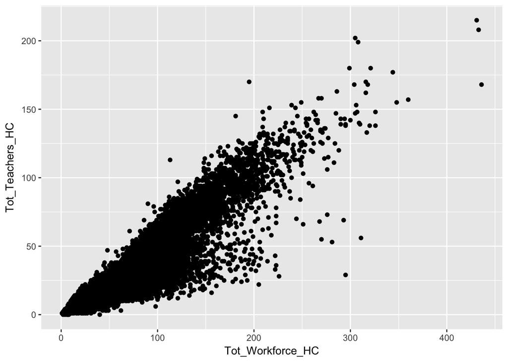

```r
ggplot(swfc_16,aes(Tot_Workforce_HC,Tot_Teachers_HC)) +
  geom_point()
```

**Activity A7.2:** Explain the arguments in this graph.

##### **Bar charts:**

We can use bar charts to do simple counts of the number of observations belonging to each level. In the example below we use the geom_bar() function to count the number of schools of each school type:

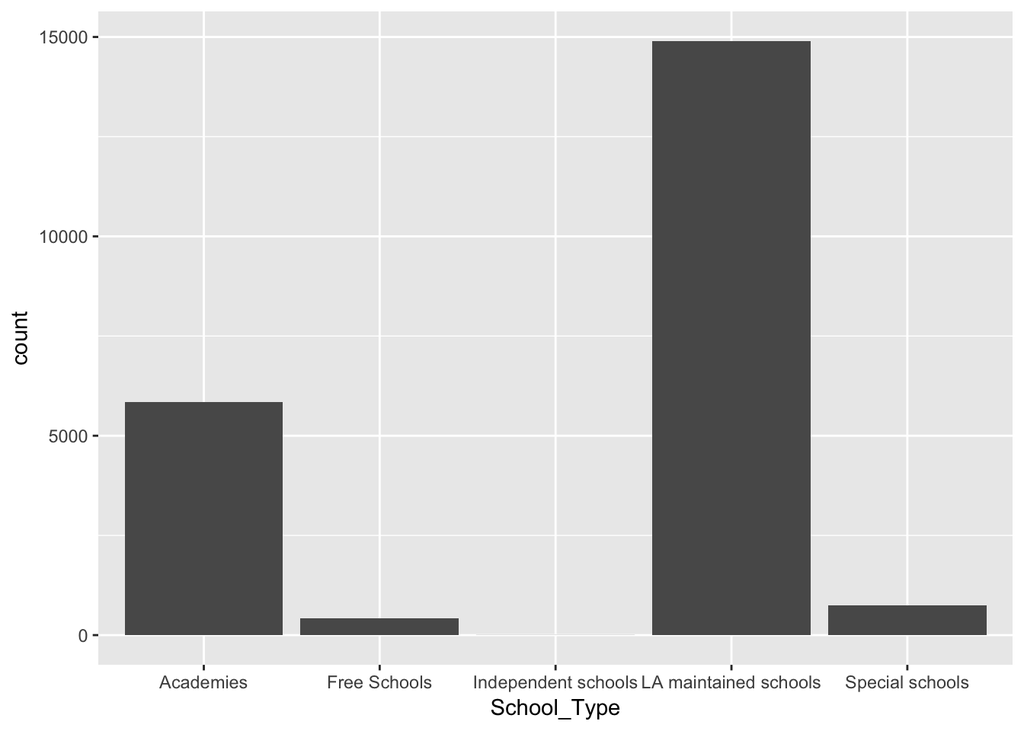

```r
ggplot(swfc_16,aes(School_Type)) +
  geom_bar()
```

**Activity A7.3:** What’s different about the aes() function and why?

However, as well as counts we can use bar charts to display the values within the column of a dataframe. Here we calculate the average percentage of teachers with qualified teacher status for each school type.

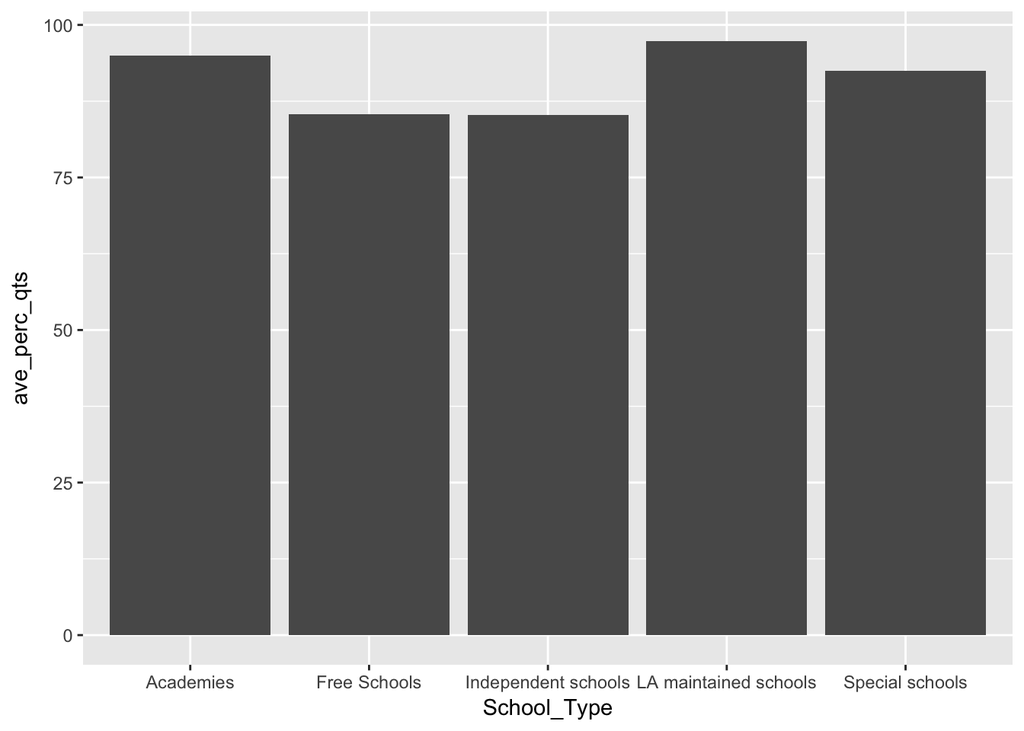

```r
ggplot(swfc_16 %>% group_by(School_Type) %>% summarise(ave_perc_qts = mean(Perc_QTS_Teachers,na.rm=TRUE)),
       aes(School_Type,ave_perc_qts)) +
  geom_bar(stat="identity")
```

Let’s break down the arguments:

- The first argument within ggplot() is a dplyr script to create a dataframe which contains each school type and its average percentage of qualified teachers. This negates the need to, every time, create a named dataframe.

**Activity A7.4:** Highlight the first argument and run it.

- The aes() function contains two arguments this time - the x-axis and the y-axis. We need to define a y-axis because we’re going to be using values from a column, not just counts.
- The geom_bar() function contains an argument, stat=‘identity’, which informs the plot that it’s to use the values from a column (in this instance the ave column created in the first argument of ggplot()).

##### **Line graphs:**

**Activity A7.5:** Adjust the code above for the bar graph to produce a line graph:

- Replace geom_bar(stat=“identity”) with geom_line()
- Change the columns used to see how the TA:Teacher ratio (TA_Teacher_Ratio) varies with the total number of teachers in a school (Tot_Teachers_HC).

A word of warning with line graphs though: you can use bar charts and line graphs to display changes between discrete numerical data (e.g. 1,2,3,4,5), but you should not use a line graph to display changes between categorical data (e.g. primary schools, secondary schools, special schools). This is because a line graph implies some sort of continuous variation, so each mark has a ‘distance’ from the previous (e.g. the distance between 2 and 1 is 1), but there’s no ‘distance’ between primary school and secondary school.

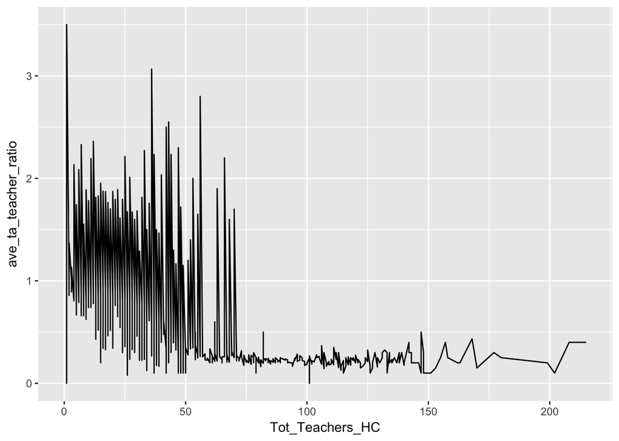

```r
ggplot(swfc_16 %>% group_by(Tot_Teachers_HC,School_Type) %>% summarise(ave_ta_teacher_ratio = mean(TA_Teacher_Ratio,na.rm=TRUE)),
       aes(Tot_Teachers_HC,ave_ta_teacher_ratio)) +
  geom_line()
```

##### **Displaying a third variable:**

We can use ggplot to plot three variables, not just two on the x and y axes. This allows the viewer to get a more detailed breakdown of the data, without having to produce multiple graphs.

There are three different arguments which can be added to the aesthetic function (as they’re going to change how the graph looks), depending on what type of graph is being produced:

- fill= is used for bar graphs - this splits up each bar with different colours related to the proportion of each category making up that bar
- col= is used for line graphs - this creates lines of different colours for each different category to show how it varies
- size= is used for scatter plot - the size of each point relates to the value in the column

In all of these arguments, after the equals sign comes the variable name that we want to plot.

Here’s an bar chart example which uses fill which shows the proportions of each type of school which make up each region.

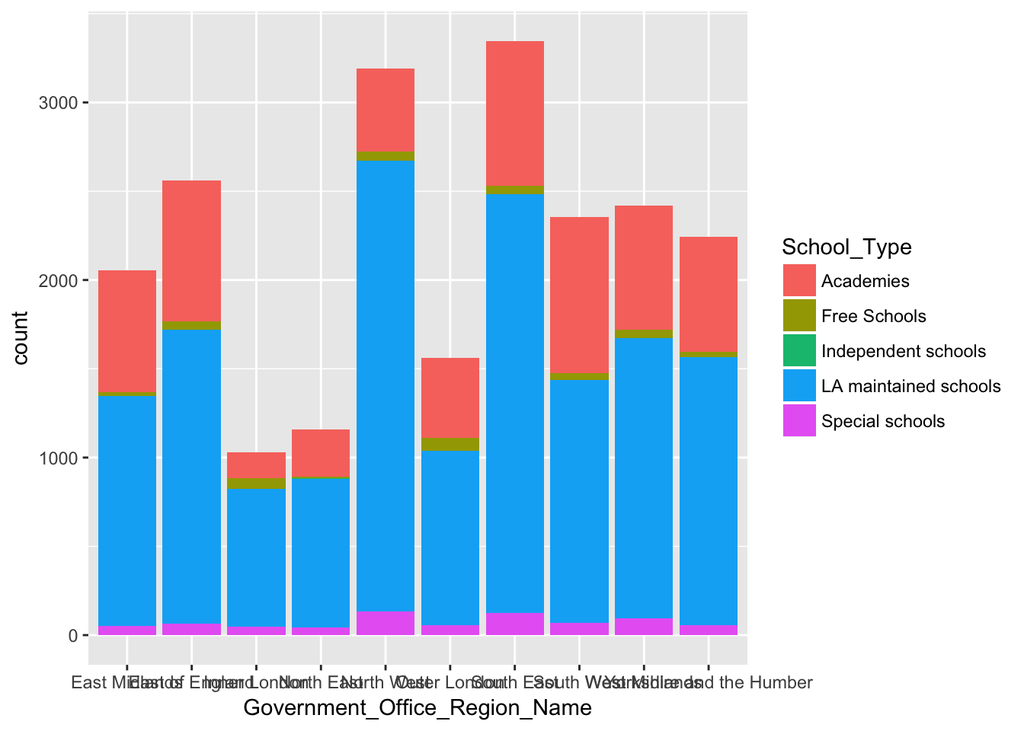

**Activity A7.6:** Use col to adapt the line graph above to show how different each different school type’s TA:Teacher ratio varies with size of school.

Finally, we’re going to use size to show a third variable on a scatterplot.

**Activity A7.7:** Use the group_by and summarise functions in dplyr to create a dataframe which has four columns:

- Government Office Regions
- The average pay (Mean_Gross_Salary_All_Teachers_Sterling) for each of those regions
- The average percentage of teachers receiving allowances (Perc_Receive_Allowance_Qual_Classroom_Teachers) in each region
- The number of schools in each region (use n())

Your code in the summarise function will look something like:

```r
summarise(var1_name = mean(variable1,na.rm=FALSE),
          var2_name = mean(variable2,na.rm=FALSE),
          var3_name = n())
```

**Activity A7.8:** Pop your dataframe code from the activity above into a ggplot function, and create a scatter plot with the col argument as the region and the size argument as the number of schools in that region.

It may seem like it should be fill not col for colouring points, but remember that a point shouldn’t really have a size - it’s an exact location, so there’s nothing to fill!